# Modeling Patterns in Public Attention to Migration Using Google Trends

Author

Holden Peacock and David Rios

Published

October 21, 2026

Abstract

This report examines the Google search interest for the search term ‘’migration’’ from 2004 to 2026. Using data from Google Trends, we explore the trends and seasonality in the data, and model the errors in the data using a Moving Average (1) model. We find that after accounting for the trends and seasonality in our data, there are two periods of increased search volume that persist due to the United States political environment and increases in news coverage regarding immigration. This suggests that the public strongly reacts to political events, driving increases in search volume.

## Introduction

Human history has always been defined by migration. Whether voluntary (seeking work or education) or involuntary (fleeing conflict or environmental degradation), people move across borders and regions for complex reasons. In the United States, following the second presidential election of Donald Trump in 2024, migration and immigration have been some of the largest topics in politics and U.S. culture. While U.S. immigration policy has always been a primary topic in political debate, it has become especially common because of Donald Trump’s immigration policies implemented shortly after his return to office in 2025. When we look at the literature, it’s clear to see that to understand migration, we must first understand the political context. While (Durand and Massey 2019) traces how Mexico–U.S. migration has changed over the decades in response to policy shifts and border enforcement, (Nagel 2025) examines how MAGA rhetoric and Trump’s campaigns have brought immigration back to the center of national debate. Regarding internal migration in the United States, recent trends indicate that long-distance migration rates within the U.S. are lower than they have been in decades (Molloy et al. 2011). Because of the recent trends in policy regarding immigration, migration has likely been googled now more than ever, and it will be interesting to see how recent trends compared to the past.

## Data

For this project, we will explore U.S. monthly Google Trends data from 2004 to the present on the search term “migration”. The total number of observations is 273. Google Trends is a platform that measures the popularity of search topics on Google searches over time. The “migration” search data is a time series that measures the relative search volume of the search term “migration” over time.

The original data source contains two variables. One variable measures the relative search volume of the search term on a standardized scale, from 0 to 100. These are not counts, and the values come from a sample. In this form, 100 indicates the peak volume of search terms for the topics over the time frame. We drop the last observation, the month of October 2026, because it was incomplete at the time of the study. The other variable indicates the date of measurement.

As shown in the initial visualization below, search interest has risen over the past four years, consistent with literature explained earlier. The series highlights two key periods of heightened activity: an initial spike spanning late 2023 through early 2024, and a maximum index of 100 during early 2026. The first spike coincided with Trump’s candidacy announcement and MAGA agenda, whereas the 2026 peak aligned with large-scale enforcement under the Metro Surge Operation. Ultimately, these dynamics illustrate how search volume for migration search terms is intertwined with national political events. We will used these two at indicator variables later on this project.

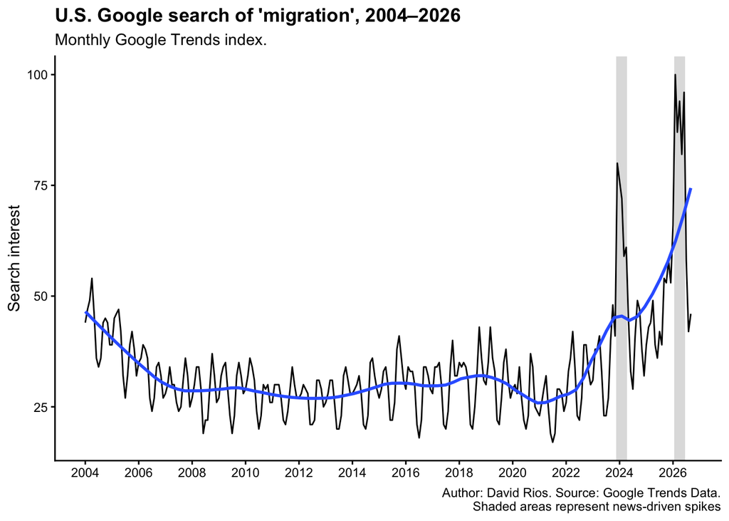

## Methods

To estimate the trends in our data, we used a regression-based B-spline model (R Core Team 2026). We placed B-spline knots at 2015, 2020, and 2023 to capture long-term non-linear shifts in the search trends. To de-trend our data, we calculated the residuals between our observed search data and the estimated trends at each point in time in our model. We used a linear model to estimate and remove the seasonality from our data. To capture seasonality in our data, we used 12 categorical monthly indicator variables. We added two indicator variables to address non-stationarity and variance spikes:

- Dec 2023–Apr 2024 (Trump campaign launch and MAGA platform announcements).
- Feb 2026–Jun 2026 (Metro Surge Operation and deportation coverage).

After modeling and estimating our seasonality, we removed the seasonality by calculating the residuals between our detrended data and the seasonality estimates. This left us with only correlated noise.

To model the leftover correlated noise, we analyzed the sample autocorrelation function and partial autocorrelation function of the residuals. Based on the lag structure, several candidate models were evaluated for the error term using Akaike’s Information Criterion (AIC), Bayesian Information Criterion (BIC), coefficient significance, and standardized residual diagnostic plots. Ultimately, we chose a Moving Average(1) model to model our correlated noise:

$$Y_t = W_t + \theta W_{t-1}, \quad W_t \sim N(0, \sigma^2_w)$$

Similarly, to make forecasts from our model, we used the `sarima_for()` function in `astsa` (Stoffer 2025). Using this function, we can input information from our MA(1) model, as well as our trend and seasonality regressions, to make predictions about the future.

## Results

### Trend and seasonality

We model the trend in our data using B-splines. Shown below in red, the B-Spline follows the data very well, capturing the decreasing trend early on in the data, then the changes post-COVID and especially after 2023 and the beginning of Trump’s second presidential campaign.

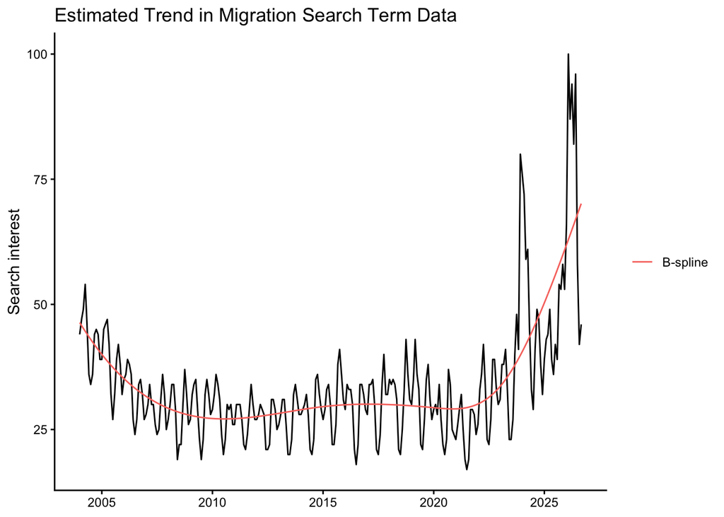

Evaluating the detrended data, we can see that there is constant seasonality throughout the data until around 2023. The seasonality shows that interest generally increases in the spring, dips in the summer, and then peaks again in the fall. Only the most recent years (2023–2026) break from the pattern, with big jumps from December to March.

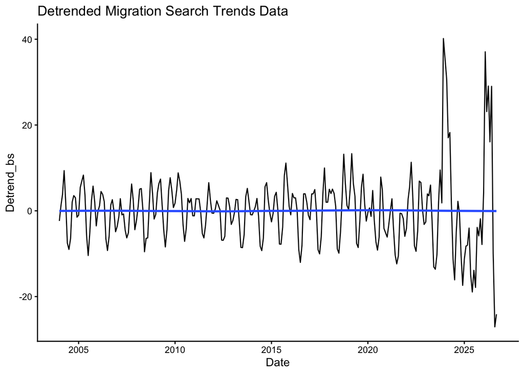

To model seasonality in the migration data, we fit a linear regression model to the detrended spline series, with categorical indicator variables to indicate each month in the year. We added additional indicator variables to address large spikes in 2024 and 2026. The plot below demonstrates the seasonal trends, shown in red, before 2023. It shows that prior to 2023, there were generally seasonal peaks around March and October in the search volume of “migration”, with a dip during the summer months. We find that because of the large spikes in 2024 and 2026, seasonality is less consistent during those years.

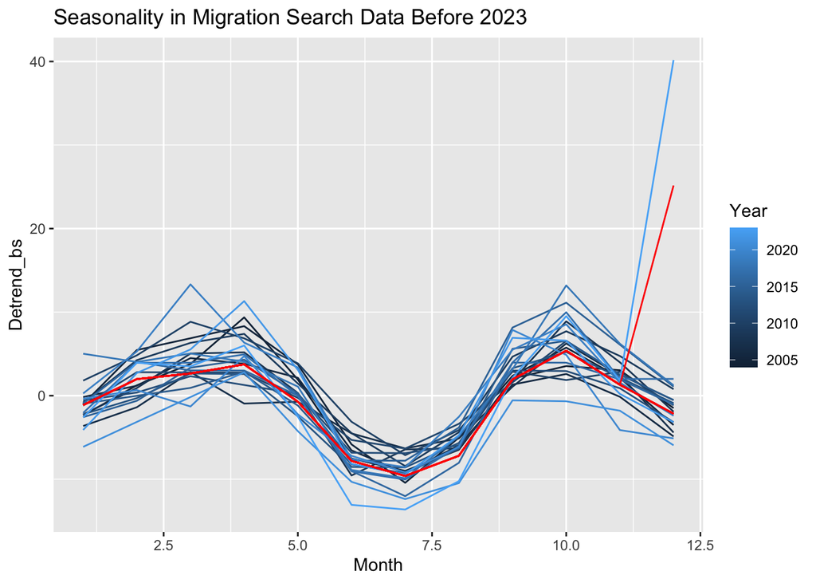

Evaluating the detrended data with seasonality and news indicators removed, we can see that the errors are centered around zero, and it looks like mostly random noise. However, after 2023, the errors are much larger than they were in previous years in the dataset. This indicates that there are outside influences on the data, likely news or politics, that cannot be captured in trend or seasonality, even when accounting for these spikes in our model.

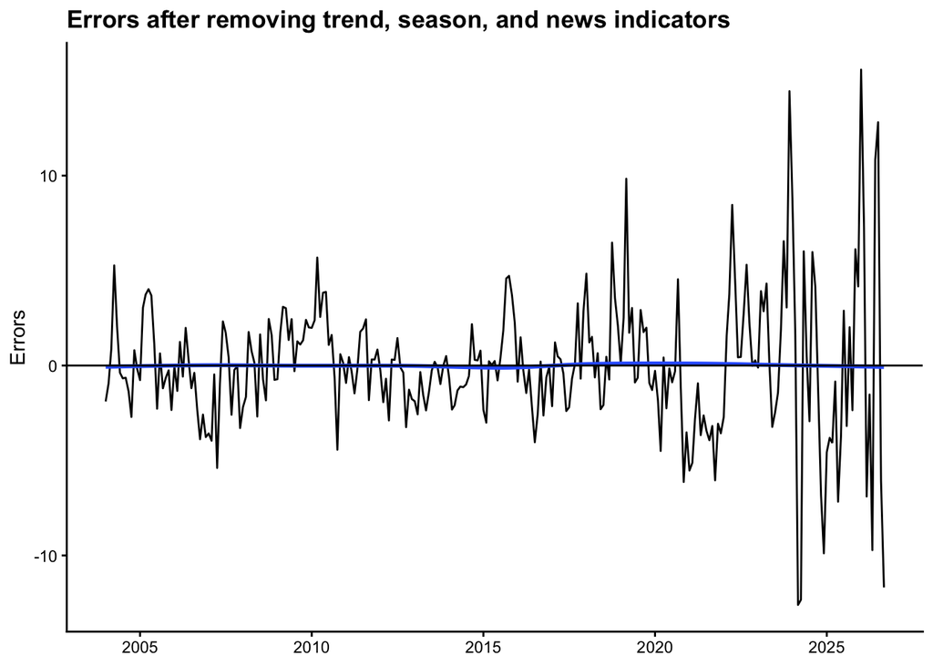

The regression coefficients show strong seasonal and shock-driven effects. Holding month and overall trend constant, search interest increased by an estimated 30.66 points during the late 2023–early 2024 period and by 39.16 points during the early 2026 period, and both estimates are significant at the 1% level.

Estimated size of the two high-interest periods

|  | Estimate | Std. Error | t value | Pr(>\|t\|) |
| --- | --- | --- | --- | --- |
| news24 | 30.66 | 1.81 | 16.95 | 0 |
| news26 | 39.16 | 2.12 | 18.51 | 0 |

### Model Comparison

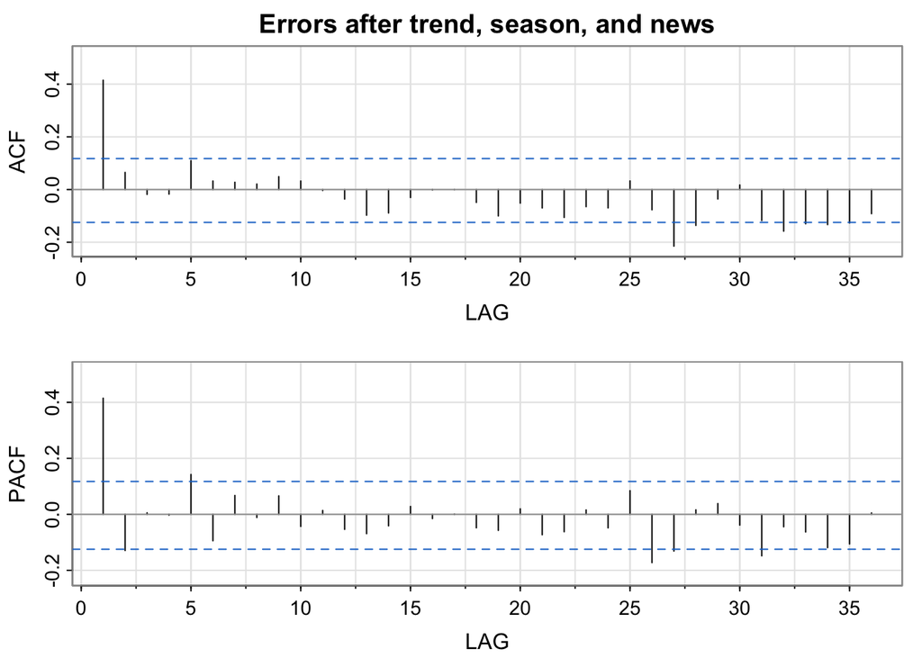

The ACF of the errors shows a strong spike at lag 1 and then drops to zero, with no clear autocorrelation at later lags. We do notice that at lag 27, the residuals fall slightly outside the bounds, but we’re not worried as this might be due to the news-driven abnormalities explained earlier. On the other hand, the PACF decays to zero. It is large at lag 1, turns negative at lag 2, and then stays near zero. An ACF that drops to zero after lag 1 together with a PACF that decays to zero is the pattern we expect from an MA(1) process.

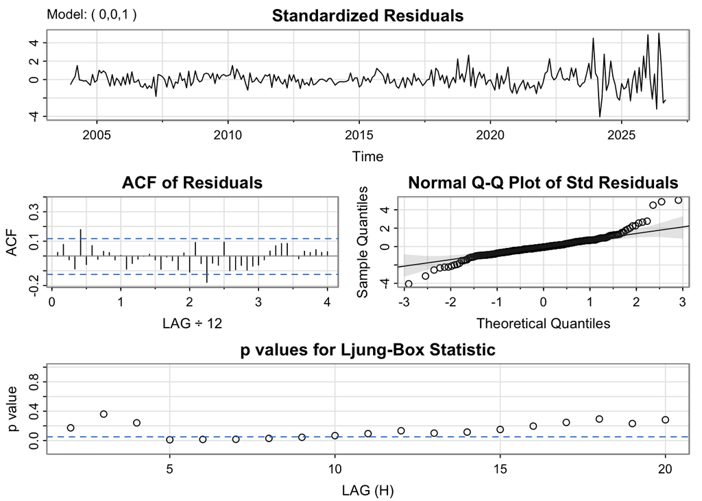

Diagnostics for the chosen MA(1) model.

In our case, the MA(1) coefficient is estimated at $\hat{\theta} = 0.46$ (SE $= 0.06$), meaning each month’s random shock carries over partly into the next month but no further.

### Forecast

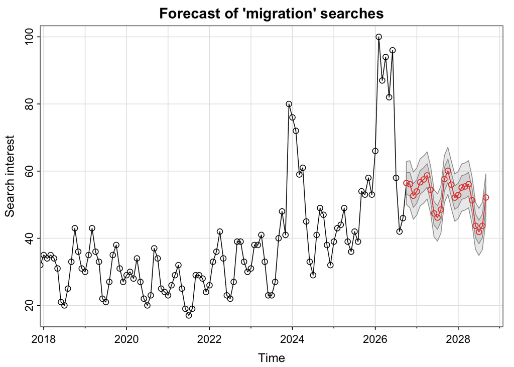

## Conclusions

Our results show that after an initial decline in interest between 2004 and 2006, U.S. interest in “migration” stayed flat from 2006 to around 2020. The search interest then rose sharply after 2023. After accounting for this trend with a B-spline, the two news-driven periods still stand out. This suggests that public attention to migration responds strongly to political events, rather than only growing gradually over time. The seasonal pattern, with peaks in spring and fall and a dip in summer, may reflect the school calendar or searches about animal migration.

Our analysis has several limitations. Google Trends reports a relative, sampled index rather than actual search counts, and the term “migration” also captures searches unrelated to immigration, such as bird or data migration. Finally, the forecast extends the B-spline beyond the data and assumes no new news-driven spikes, so the actual search interest could be much higher if another major political event occurs.

## Acknowledgements

We want to thank Prof. Brianna Heggeseth for her support throughout this process.

## References

Durand, Jorge, and Douglas S. Massey. 2019. “Evolution of the Mexico-u.s. Migration System: Insights from the Mexican Migration Project.” *The ANNALS of the American Academy of Political and Social Science* 684 (1): 21–42. https://doi.org/10.1177/0002716219857667.

Molloy, Raven, Christopher L. Smith, and Abigail Wozniak. 2011. “Internal Migration in the United States.” *Journal of Economic Perspectives* 25 (3): 173–96. https://doi.org/10.1257/jep.25.3.173.

Nagel, Caroline. 2025. “Immigration Policy in the Second Trump Administration: Restriction, Removal, and the Limits of MAGA Nativism.” *The Geographical Journal* 191 (4): e70015.

R Core Team. 2026. *R: A Language and Environment for Statistical Computing*. R Foundation for Statistical Computing. https://doi.org/10.32614/R.manuals.

Stoffer, David. 2025. *Astsa: Applied Statistical Time Series Analysis*. https://doi.org/10.32614/CRAN.package.astsa.